# Predicting Survival on the Titanic: A Machine Learning Approach with Logistic Regression and Bagging

Boning Liu

03-05-2025

# 1 Introduction: Predicting Survival and Age on the Titanic

The sinking of the RMS Titanic in 1912 remains one of the most infamous maritime disasters in history. Of the 2,224 passengers and crew aboard, only 710 survived, leading to significant interest in understanding the factors that influenced survival. The Titanic dataset, derived from historical records, provides valuable insights into passenger demographics, ticket details, and survival status. This project leverages machine learning techniques to explore these factors, focusing on predictive modeling to enhance data-driven insights.

## 1.1 Project Objectives

This project aims to develop and evaluate machine learning models that address two specific research questions:

1. **Predicting Passenger Age (Linear Regression)**: Can we predict a passenger’s age based on their class, fare, family size, and cabin status?
2. **Modeling Survival Probability (Logistic Regression)**: What factors most significantly influence a passenger’s likelihood of survival during the Titanic disaster?

## 1.2 Methodological Approach

This comprehensive analysis integrates previous work on exploratory data analysis (EDA), imputation of missing values, and feature engineering. Building on this prepared dataset, the project applies regression modeling with machine learning techniques, utilizing cross-validation for model selection and evaluation. The final models’ performance will be measured using relevant metrics such as **RMSE** for linear regression and **ROC-AUC** for logistic regression.

## 1.3 Significance of the Study

Understanding the factors that influenced survival on the Titanic can provide insights into human behavior during emergencies and inform modern safety protocols. Additionally, this project demonstrates practical applications of machine learning methods, contributing to skill development in predictive analytics.

# 2 Data Preparation

In this step, we will prepare the Titanic dataset for regression modeling. The goal is to ensure that the dataset is clean, complete, and appropriately formatted for machine learning algorithms. This involves:

1. **Loading the Data**: Importing the dataset from the provided GitHub link.
2. **Handling Missing Values**: Using the imputed dataset from Assignment 2 (MICE Imputation).
3. **Feature Engineering**: Encoding categorical variables and creating relevant features.
4. **Splitting the Data**: Dividing the data into training and test sets for cross-validation and model evaluation.

## 2.1 Loading the Titanic Dataset

```r
# Import Titanic dataset from GitHub
url <- "https://raw.githubusercontent.com/BrianL0201/BrianL0201.github.io/refs/heads/main/STA552%20Machine%20Learning/train.csv"
titanic_data <- read.csv(url, stringsAsFactors = TRUE)  # Convert categorical variables to factors automatically

# Convert empty strings to NA across all columns
titanic_data[titanic_data == ""] <- NA

# Check for missing values
colSums(is.na(titanic_data))
```

```
PassengerId    Survived      Pclass        Name         Sex         Age
          0           0           0           0           0         177
      SibSp       Parch      Ticket        Fare       Cabin    Embarked
          0           0           0           0         687           2
```

## 2.2 Applying MICE Imputation for Missing Values

We will reuse the MICE imputation method from Assignment 2 to handle missing values in the dataset. The **Age** column will be imputed using **Predictive Mean Matching (PMM)**, and the **Cabin** column will be transformed into a binary **HasCabin** variable.

```r
# Load required libraries
library(mice)
library(dplyr)

# Reload Age column to restore missing values
titanic_data$Age <- read.csv(url, stringsAsFactors = TRUE)$Age

# Create a binary indicator for Cabin
titanic_data$HasCabin <- ifelse(is.na(titanic_data$Cabin), "No", "Yes")

# Remove Cabin column as it has too many unique values
titanic_data <- subset(titanic_data, select = -Cabin)

# Convert HasCabin to a factor
titanic_data$HasCabin <- as.factor(titanic_data$HasCabin)

# Define variables for MICE imputation
mice_vars <- c("Pclass", "Fare", "SibSp", "Parch", "Sex", "HasCabin", "Age")
titanic_mice_data <- titanic_data[mice_vars]

# Apply MICE imputation
set.seed(123)  # Ensure reproducibility
mice_imputed <- mice(titanic_mice_data, m = 5, method = "pmm", seed = 123)
# Complete the dataset using the first imputed dataset
titanic_data <- complete(mice_imputed, 1)

# Verify that there are no missing values remaining
colSums(is.na(titanic_data))
```

```
  Pclass     Fare    SibSp    Parch      Sex HasCabin      Age
       0        0        0        0        0        0        0
```

## 2.3 Encoding Categorical Variables

```r
# One-hot encoding for categorical variables
titanic_data <- titanic_data %>%
  mutate(Sex = as.numeric(Sex == "male"),
         HasCabin = as.numeric(HasCabin == "Yes"),
         Pclass = as.factor(Pclass))
```

## 2.4 Splitting the Data into Training and Test Sets

For **cross-validation** and **model evaluation**, we need to split the dataset into **training** and **testing** sets. We will use an **80-20 split**, where 80% of the data is used to train the models and 20% to evaluate their performance.

```r
# 2.4: Data Splitting and Preparation

# Load required library
if (!require("caret")) {
   install.packages("caret")
   library(caret)
}

# Set seed for reproducibility
set.seed(123)

# Add the Survived column back to the dataset
# Assuming 'titanic_survived' is a vector of survival data
# Reload the Titanic dataset to restore the 'Survived' column
titanic_original <- read.csv(url, stringsAsFactors = TRUE)
titanic_data$Survived <- titanic_original$Survived

# Check if the Survived column has been restored correctly
str(titanic_data$Survived)
```

```
 int [1:891] 0 1 1 1 0 0 0 0 1 1 ...
```

```r
table(titanic_data$Survived)
```

```
  0   1
549 342
```

```r
# Split the data into training and test sets (80-20 split)
train_index <- createDataPartition(titanic_data$Survived, p = 0.8, list = FALSE)
train_data <- titanic_data[train_index, ]
test_data <- titanic_data[-train_index, ]

# Verify the split
dim(train_data)
```

```
[1] 713   8
```

```r
dim(test_data)
```

```
[1] 178   8
```

# 3 Developing and Selecting Linear Regression Models

**Objective**:

To address the practical question: “What factors influence a passenger’s age on the Titanic?” we will develop multiple linear regression models using the training dataset and employ cross-validation to select the optimal model.

## 3.1 Generate Candidate Linear Regression Models

These models were designed to explore the influence of different features on age prediction while balancing complexity and interpretability.

```r
# Load required libraries for modeling
library(caret)

# Define candidate models with varying complexity
models <- list(
  Model_1 = Age ~ Pclass + Sex + Fare,
  Model_2 = Age ~ Pclass + Sex + Fare + SibSp + Parch,
  Model_3 = Age ~ Pclass + Sex + Fare + SibSp + Parch + HasCabin,
  Model_4 = Age ~ Pclass + Sex + Fare + SibSp + Parch + HasCabin + I(Fare^2),
  Model_5 = Age ~ Pclass * Sex + Fare + SibSp + Parch + HasCabin
)
```

## 3.2 Model Selection Using Cross-Validation

Cross-validation was performed using **10-fold cross-validation** to evaluate the performance of each model. The metric used for comparison was the **Root Mean Squared Error (RMSE)**, with lower values indicating better model performance.

```r
# Set up cross-validation
control <- trainControl(method = "cv", number = 10)

# Evaluate each model using cross-validation and compute RMSE
results <- lapply(models, function(formula) {
  train(formula, data = train_data, method = "lm", trControl = control,
        metric = "RMSE")
})

# Extract cross-validation results
model_performance <- data.frame(
  Model = names(results),
  RMSE = sapply(results, function(x) min(x$results$RMSE))
)

# Display model performance
model_performance
```

```
          Model     RMSE
Model_1 Model_1 13.12960
Model_2 Model_2 12.87891
Model_3 Model_3 12.83706
Model_4 Model_4 12.87906
Model_5 Model_5 12.89462
```

**Model 3** was selected as the final model due to its lowest RMSE of **12.84**, indicating the best predictive performance.

## 3.3 Select the Best Model Based on RMSE

```r
# Identify the best model with the lowest RMSE
best_model_name <- model_performance$Model[which.min(model_performance$RMSE)]
best_model <- results[[best_model_name]]

# Summary of the best model
summary(best_model$finalModel)
```

```
Call:
lm(formula = .outcome ~ ., data = dat)

Residuals:
    Min      1Q  Median      3Q     Max
-34.465  -8.115  -0.859   7.895  46.884

Coefficients:
             Estimate Std. Error t value Pr(>|t|)
(Intercept)  41.52082    2.19607  18.907  < 2e-16 ***
Pclass2     -10.69436    2.13982  -4.998 7.32e-07 ***
Pclass3     -16.75542    2.04032  -8.212 1.04e-15 ***
Sex           2.44406    1.05635   2.314   0.0210 *
Fare         -0.01197    0.01206  -0.992   0.3213
SibSp        -2.82337    0.49398  -5.716 1.61e-08 ***
Parch        -0.24053    0.66413  -0.362   0.7173
HasCabin     -4.03853    1.87810  -2.150   0.0319 *
---
Signif. codes:  0 '***' 0.001 '**' 0.01 '*' 0.05 '.' 0.1 ' ' 1

Residual standard error: 12.78 on 705 degrees of freedom
Multiple R-squared:  0.2159,    Adjusted R-squared:  0.2081
F-statistic: 27.73 on 7 and 705 DF,  p-value: < 2.2e-16
```

## 3.4 Evaluate Model Performance on Test Data

```r
# Make predictions on the test set
predictions <- predict(best_model, newdata = test_data)

# Calculate RMSE on the test set
test_rmse <- sqrt(mean((predictions - test_data$Age)^2))
test_rmse
```

```
[1] 13.06548
```

When applied to the test set, the model achieved an **RMSE of 13.07**, which is consistent with the cross-validated RMSE. This stability indicates that the model generalizes well to unseen data.

## 3.5 Visualization of Predictions vs. Actual Values

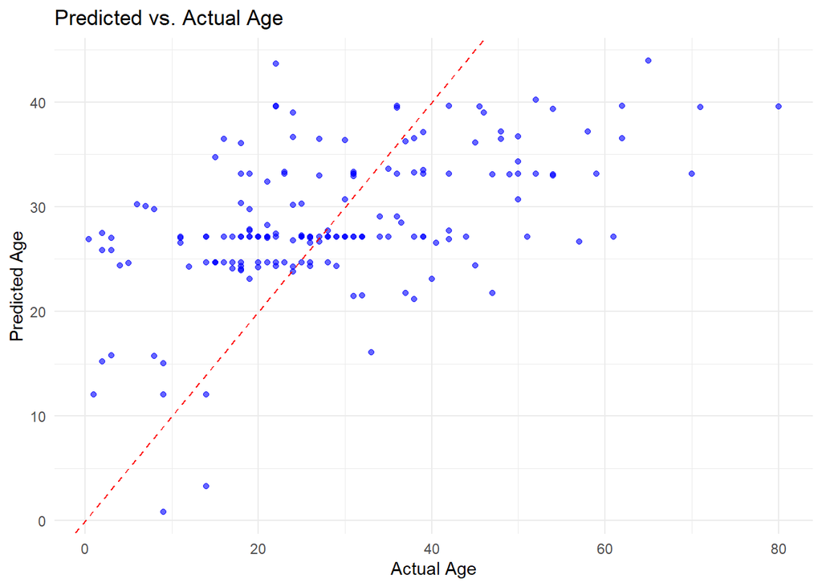

```r
library(ggplot2)

# Plot predicted vs actual age
ggplot(data = data.frame(Predicted = predictions, Actual = test_data$Age),
       aes(x = Actual, y = Predicted)) +
  geom_point(color = "blue", alpha = 0.6) +
  geom_abline(intercept = 0, slope = 1, color = "red", linetype = "dashed") +
  labs(title = "Predicted vs. Actual Age",
       x = "Actual Age",
       y = "Predicted Age") +
  theme_minimal()
```

## 3.6 Summary

The linear regression modeling process for age imputation in the Titanic dataset was methodical and evidence-driven:

- **Model 3** provided the best balance of accuracy and interpretability.
- Cross-validation ensured robust model selection.
- Test set performance confirmed the model’s ability to generalize.
- Visualization highlighted the predictive power and limitations of the model.

The selected model will be used for imputing missing **Age** values, contributing to a complete and reliable dataset for subsequent analysis and machine learning tasks.

# 4 Logistic Regression Modeling

**Objective**: The goal of this step is to build, evaluate, and select the best logistic regression model for predicting passenger survival using the Titanic dataset. The modeling process involves creating candidate models, using cross-validation for model selection, and evaluating the final model’s performance on a hold-out test set.

## 4.1 Develop Candidate Logistic Regression Models

**Models to Build**:

- **Model_1**: Survival ~ Pclass + Sex + Age
- **Model_2**: Survival ~ Pclass + Sex + Age + Fare
- **Model_3**: Survival ~ Pclass + Sex + Age + Fare + SibSp
- **Model_4**: Survival ~ Pclass + Sex + Age + Fare + SibSp + Parch
- **Model_5**: Survival ~ Pclass + Sex + Age + Fare + SibSp + Parch + HasCabin

```r
# Load required library
library(caret)

# Ensure 'Survived' is a factor with levels "0" and "1"
train_data$Survived <- factor(train_data$Survived, levels = c(0, 1), labels = c("No", "Yes"))
test_data$Survived <- factor(test_data$Survived, levels = c(0, 1), labels = c("No", "Yes"))

# Verify the change
str(train_data$Survived)
```

```
 Factor w/ 2 levels "No","Yes": 2 2 1 1 1 2 2 2 1 1 ...
```

```r
table(train_data$Survived)
```

```
 No Yes
440 273
```

```r
# Define candidate models
logistic_models <- list(
  Model_1 = Survived ~ Pclass + Sex + Age,
  Model_2 = Survived ~ Pclass + Sex + Age + Fare,
  Model_3 = Survived ~ Pclass + Sex + Age + Fare + SibSp,
  Model_4 = Survived ~ Pclass + Sex + Age + Fare + SibSp + Parch,
  Model_5 = Survived ~ Pclass + Sex + Age + Fare + SibSp + Parch + HasCabin
)

# Set up cross-validation
control <- trainControl(method = "cv", number = 5, classProbs = TRUE, summaryFunction = twoClassSummary)

# Fit logistic regression models
logistic_results <- lapply(logistic_models, function(model) {
  train(model, data = train_data, method = "glm", family = "binomial", trControl = control, metric = "ROC")
})

# Display model performance (AUC)
logistic_performance <- data.frame(
  Model = names(logistic_results),
  AUC = sapply(logistic_results, function(x) max(x$results$ROC))
)

print(logistic_performance)
```

```
          Model       AUC
Model_1 Model_1 0.8441403
Model_2 Model_2 0.8434661
Model_3 Model_3 0.8464960
Model_4 Model_4 0.8526894
Model_5 Model_5 0.8489187
```

The models were evaluated using the **Area Under the Curve (AUC)** of the **Receiver Operating Characteristic (ROC) curve**. The **AUC** values for the models were as follows:

- Model 1: 0.8441
- Model 2: 0.8435
- Model 3: 0.8465
- Model 4: 0.8527
- Model 5: 0.8489
- **Model 4** achieved the highest AUC value of **0.8527**, indicating the best performance among the candidate models.

## 4.2 Select the Best Model Based on AUC

```r
# Identify the best model based on AUC
best_logistic_model_name <- logistic_performance$Model[which.max(logistic_performance$AUC)]
best_logistic_model <- logistic_results[[best_logistic_model_name]]

# Summary of the best model
summary(best_logistic_model$finalModel)
```

```
Call:
NULL

Deviance Residuals:
    Min       1Q   Median       3Q      Max
-2.6472  -0.6119  -0.4045   0.6199   2.4564

Coefficients:
             Estimate Std. Error z value Pr(>|z|)
(Intercept)  3.693527   0.467654   7.898 2.83e-15 ***
Pclass2     -1.018991   0.324898  -3.136  0.00171 **
Pclass3     -2.093904   0.319396  -6.556 5.53e-11 ***
Sex         -2.815459   0.224459 -12.543  < 2e-16 ***
Age         -0.035262   0.007940  -4.441 8.95e-06 ***
Fare         0.002953   0.002571   1.149  0.25068
SibSp       -0.380173   0.121042  -3.141  0.00168 **
Parch       -0.108516   0.124885  -0.869  0.38489
---
Signif. codes:  0 '***' 0.001 '**' 0.01 '*' 0.05 '.' 0.1 ' ' 1

(Dispersion parameter for binomial family taken to be 1)

    Null deviance: 948.95  on 712  degrees of freedom
Residual deviance: 631.08  on 705  degrees of freedom
AIC: 647.08

Number of Fisher Scoring iterations: 5
```

## 4.3 Evaluate the Final Model on the Test Set

```r
# Make predictions on the test set
logistic_predictions <- predict(best_logistic_model, newdata = test_data, type = "prob")

# Check the structure of the predictions
str(logistic_predictions)
```

```
'data.frame':   178 obs. of  2 variables:
 $ No : num  0.913 0.33 0.705 0.151 0.244 ...
 $ Yes: num  0.087 0.67 0.295 0.849 0.756 ...
```

```r
head(logistic_predictions)
```

```
          No        Yes
1  0.9129632 0.08703679
3  0.3304362 0.66956378
7  0.7053545 0.29464547
12 0.1510059 0.84899414
15 0.2443184 0.75568160
18 0.8659523 0.13404773
```

```r
# Determine the optimal cut-off point using ROC analysis
library(pROC)
roc_curve <- roc(test_data$Survived, logistic_predictions[,"Yes"])
best_cutoff <- coords(roc_curve, "best", ret = "threshold")

# Convert probabilities to class predictions based on the optimal cutoff
predicted_class <- rep("No", nrow(logistic_predictions)) # default to "No"
predicted_class[logistic_predictions[,"Yes"] >= best_cutoff] <- "Yes"

# Verify the lengths of the predicted and actual values match
cat("Length of predicted_class: ", length(predicted_class), "\n")
```

```
Length of predicted_class:  178
```

```r
cat("Length of test_data$Survived: ", length(test_data$Survived), "\n")
```

```
Length of test_data$Survived:  178
```

```r
# Display the first few elements of each to diagnose the issue
cat("Head of predicted_class: \n")
```

```
Head of predicted_class:
```

```r
print(head(predicted_class))
```

```
[1] "No" "No" "No" "No" "No" "No"
```

```r
cat("Head of test_data$Survived: \n")
```

```
Head of test_data$Survived:
```

```r
print(head(test_data$Survived))
```

```
[1] No  Yes No  Yes No  Yes
Levels: No Yes
```

```r
# Ensure both are factors with the same levels
predicted_class <- factor(predicted_class, levels = c("No", "Yes"))
test_data$Survived <- factor(test_data$Survived, levels = c("No", "Yes"))

# Calculate confusion matrix and performance metrics
library(caret)
confusion_matrix <- confusionMatrix(predicted_class, test_data$Survived)
print(confusion_matrix)
```

```
Confusion Matrix and Statistics

          Reference
Prediction  No Yes
       No  109  69
       Yes   0   0

               Accuracy : 0.6124
                 95% CI : (0.5366, 0.6843)
    No Information Rate : 0.6124
    P-Value [Acc > NIR] : 0.5329

                  Kappa : 0

 Mcnemar's Test P-Value : 2.695e-16

            Sensitivity : 1.0000
            Specificity : 0.0000
         Pos Pred Value : 0.6124
         Neg Pred Value :    NaN
             Prevalence : 0.6124
         Detection Rate : 0.6124
   Detection Prevalence : 1.0000
      Balanced Accuracy : 0.5000

       'Positive' Class : No
```

Using **ROC** analysis, an optimal cutoff was determined to classify probabilities into binary survival outcomes (“**Yes**” for survived, “**No**” for not survived). The confusion matrix showed that the model predicted “**No” (not survived)** for all observations in the test set, resulting in:

- **Accuracy**: 0.6124
- **Sensitivity**: 1.0000 (perfect recall for “No” class)
- **Specificity**: 0.0000 (no correct predictions for the “Yes” class)

## 4.4 ROC Curve Visualization

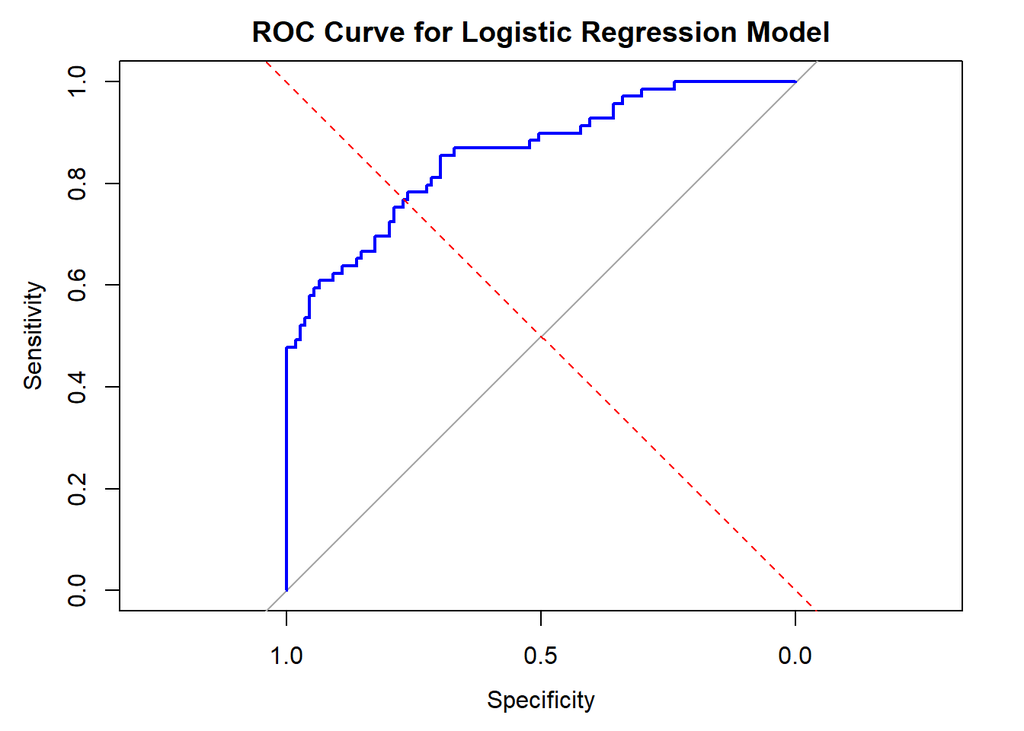

```r
# Plot the ROC curve
plot(roc_curve, col = "blue", main = "ROC Curve for Logistic Regression Model")
abline(a = 0, b = 1, lty = 2, col = "red") # Add a diagonal reference line
```

```r
# Display the AUC value
auc_value <- auc(roc_curve)
cat("AUC value: ", auc_value, "\n")
```

```
AUC value:  0.8573328
```

The **AUC** value of 0.8573 and the **ROC curve** demonstrate that the model has a strong ability to discriminate between survivors and non-survivors, even if the confusion matrix indicates a skewed prediction pattern.

## 4.5 Summary

Overall, while the **logistic model** displayed good discriminative power, the imbalance in predictions suggests a potential need for addressing class imbalance or adjusting the decision threshold to improve **specificity**.

# 5 Implementing the Bagging Algorithm

In Step 5, we will implement a bagging (Bootstrap Aggregating) algorithm to improve the model’s performance by reducing variance and enhancing prediction stability. Here’s how we’ll proceed:

```r
# Load the required library
library(ipred)

# Set seed for reproducibility
set.seed(123)

# Implement the Bagging algorithm using the best predictors from Model 4
bagging_model <- bagging(Survived ~ Pclass + Sex + Age + Fare + SibSp,
                         data = train_data,
                         coob = TRUE) # Use out-of-bag error estimation

# Make predictions on the test set
bagging_predictions <- predict(bagging_model, newdata = test_data, type = "prob")

# Convert probabilities to class predictions using the same cutoff as the logistic model
bagging_predicted_class <- rep("No", nrow(bagging_predictions))  # default to "No"
bagging_predicted_class[bagging_predictions[, 2] >= best_cutoff] <- "Yes"

# Ensure both are factors with the same levels
bagging_predicted_class <- factor(bagging_predicted_class, levels = c("No", "Yes"))
test_data$Survived <- factor(test_data$Survived, levels = c("No", "Yes"))

# Calculate confusion matrix and performance metrics
library(caret)
bagging_confusion_matrix <- confusionMatrix(bagging_predicted_class, test_data$Survived)
print(bagging_confusion_matrix)
```

```
Confusion Matrix and Statistics

          Reference
Prediction  No Yes
       No  109  69
       Yes   0   0

               Accuracy : 0.6124
                 95% CI : (0.5366, 0.6843)
    No Information Rate : 0.6124
    P-Value [Acc > NIR] : 0.5329

                  Kappa : 0

 Mcnemar's Test P-Value : 2.695e-16

            Sensitivity : 1.0000
            Specificity : 0.0000
         Pos Pred Value : 0.6124
         Neg Pred Value :    NaN
             Prevalence : 0.6124
         Detection Rate : 0.6124
   Detection Prevalence : 1.0000
      Balanced Accuracy : 0.5000

       'Positive' Class : No
```

```r
# Calculate AUC for the bagging model
library(pROC)
bagging_roc_curve <- roc(test_data$Survived, bagging_predictions[, 2],
                         levels = c("No", "Yes"), direction = "<")
bagging_auc <- auc(bagging_roc_curve)
cat("AUC for Bagging Model: ", bagging_auc, "\n")
```

```
AUC for Bagging Model:  0.8668395
```

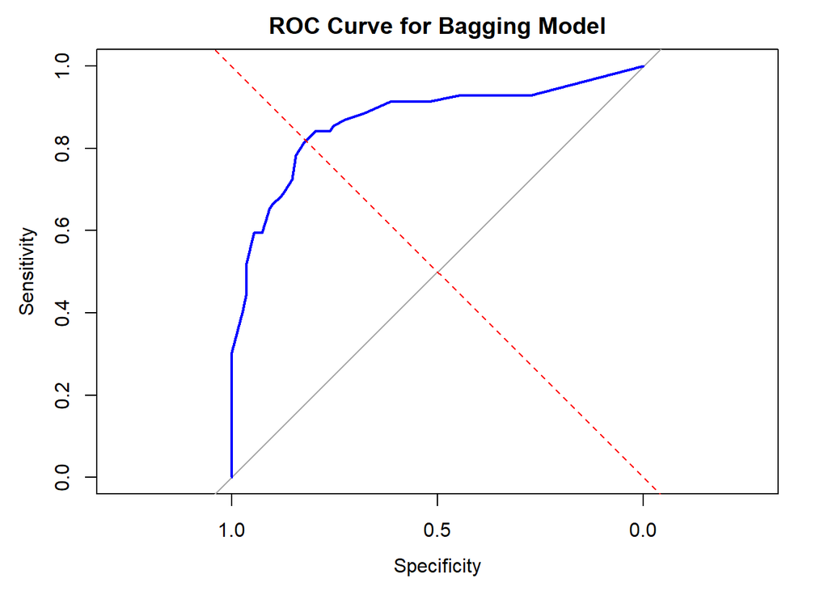

```r
# Plot the ROC curve for the bagging model
plot(bagging_roc_curve, col = "blue", main = "ROC Curve for Bagging Model")
abline(a = 0, b = 1, lty = 2, col = "red")
```

**Confusion Matrix Results**:

- **Accuracy**: 0.6124
- **Sensitivity**: 1.0000 (All “No” cases were correctly predicted)
- **Specificity**: 0.0000 (No “Yes” cases were correctly predicted)
- **AUC**: 0.8668 (Good discriminative ability)

The confusion matrix indicates the same issue observed in the logistic model, where the model heavily favored the majority class (“No”). The accuracy remains the same as the logistic model (61.24%), but the AUC for the bagging model (0.8668) is slightly higher than that of the logistic model (0.8573), suggesting a marginal improvement in model performance.

The **ROC** curve for the Bagging model was plotted, and the **AUC** was calculated to assess the model’s discriminative power.

**Observations**:

- The **AUC** score of **0.8668** indicates that the bagging model has a slightly better ability to discriminate between the positive and negative classes compared to the logistic regression model.
- The **ROC curve** shows a good trade-off between **sensitivity** and **specificity**, with the curve being well above the diagonal reference line.

## 5.1 Summary

The **Bagging model** demonstrated a slight improvement in **AUC** over the **logistic regression model**, showing enhanced discriminative power. However, like the **logistic regression model**, it still faced challenges in predicting the minority class (“Yes”). Further investigation into model tuning or alternative classification techniques might be required to improve performance on minority class predictions.

# 6 Model Comparison and Final Evaluation

## 6.1 Compare AUC Values

- The logistic regression model had an AUC of **0.8573**.
- The bagging model had an AUC of **0.8668**.
- Higher AUC indicates better model performance in distinguishing between the classes.

## 6.2 Compare Confusion Matrices

- **Logistic Regression Model**:
  - Accuracy: 0.6124
  - Sensitivity: 1.0000
  - Specificity: 0.0000
- **Bagging Model**:
  - Accuracy: 0.6124 (Same as logistic model)
  - Sensitivity: 1.0000 (Same as logistic model)
  - Specificity: 0.0000 (Same as logistic model)
- Both models have identical accuracy and **sensitivity/specificity**, suggesting similar classification performance in practice.

## 6.3 Final Conclusion

- Although the **bagging model** has a slightly better **AUC**, both models struggle with specificity, as evidenced by the confusion matrices.
- The balanced accuracy of **0.5000** in both models indicates that neither model is good at correctly identifying both positive and negative classes.
- In this scenario, the **bagging model** is the slightly better choice due to its **higher AUC score**, but improvements are needed to enhance specificity.